## Data Anlysis on COVID-19 in India

# Downloading and Prepping Data

Data downloaded or scraped from “Ministry of Health and Family Welfare” website(https:// mohfw.gov.in), and I have collected Indian states latitude and longitude from google maps as I have to plot the geospatial visualisation of corona cases throughout the country, after scrapping the data into DataFrame using pandas library, I've observed that data should be prepared for further stages as a part I have removed last three unwanted rows from the data frame and there only three columns which indicate cured, death,& total however for a better solution I have added another column “Active” for better understanding I have changed names the columns from {Name of State / UT': 'State/UT', 'Total Confirmed cases (Including 111 foreign Nationals)’:’Total', ‘Cured/Discharged/Migrated’:’Cured’}.

# Total States affected by Covid-19

As of 30 April 2020 26 states & 6 union territory have been affected with corona virus, in pandas using groupby attribute I have sorted in descending ordered from the data frame and plot as below using matplotlib.

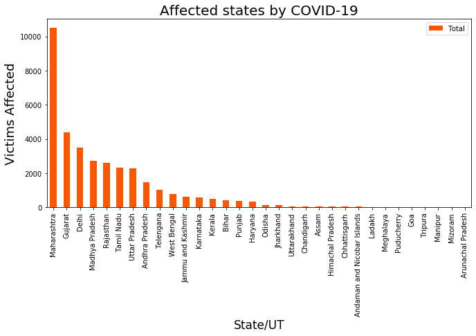

```python
total.plot(kind='bar',figsize=(11,5),color='#F95700FF')
plt.title('Affected states by COVID-19',fontsize=20)
plt.ylabel('Victims Affected',fontsize=18)
plt.xlabel('State/UT',fontsize=17)
plt.show()
```

# Top 5 states affected by COVID-19

As we know from the data Maharashtra, Gujarat, Delhi, Madhya Pradesh, & Rajasthan are being top 5, as we know the incident(Tablighi Jamaat) happen in Delhi on before lockdown as there is more crowd in the incident as they have traveled throughout the country and government recognised it as coronavirus super-spreader event, with more than 4,000 confirmed cases and at least 27 deaths linked to the event reported across the country.

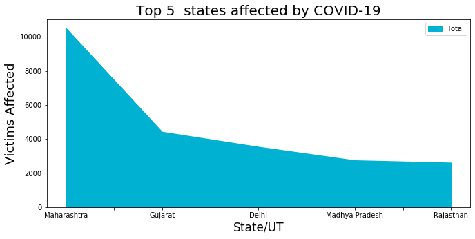

```python
tdf.plot(kind='area',figsize=(11,5),color='#00B1D2FF')
plt.title('Top 5  states affected by COVID-19',fontsize=20)
plt.xlabel('State/UT',fontsize=17)
plt.ylabel('Victims Affected',fontsize=18)
plt.show()
```

# Least affected states by Covid-19

Goa, Tripura, Manipur, Mizoram, Arunachal Pradesh are the least affected states by the coronavirus in the country. 7 corona cases in Goa, 2 corona cases in Tripura & Manipur, 1 case in Arunachal Pradesh.

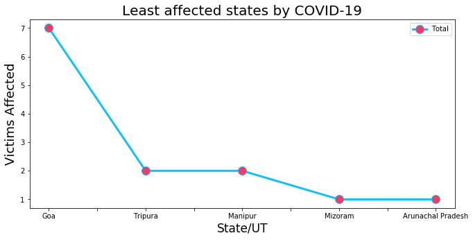

```python
ldf.plot(kind='line',figsize=(11,5),
           color='#12C0F7',
           marker='o',
           markersize=12,
           markerfacecolor='#F73A68',
           linewidth=3)
plt.title('Least affected states by COVID-19',fontsize=20)
plt.xlabel('State/UT',fontsize=17)
plt.ylabel('Victims Affected',fontsize=18)
plt.show()
```

# Active Cases in India

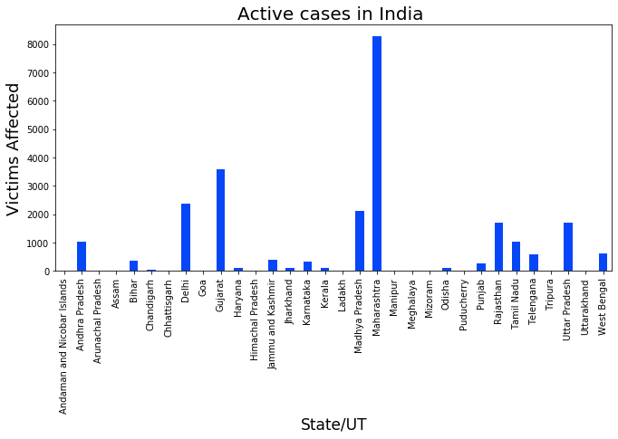

```python
active.plot(kind='bar',figsize=(11,5),color='#0547F8')
plt.title('Active cases in India ',fontsize=20)
plt.xlabel('State/UT',fontsize=17)
plt.ylabel('Victims Affected',fontsize=18)
plt.show()
```

# Top 5 states are in Active

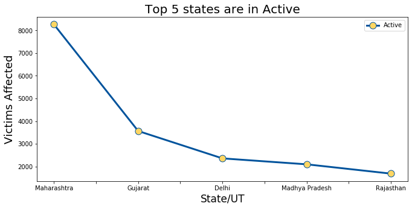

```python
adf.plot(kind='line',figsize=(11,5),
           color='#00539CFF',
           marker='o',
           markersize=11,
           markerfacecolor='#FFD662FF',
           linewidth=3)
plt.title('Top 5 states are in Active',fontsize=20)
plt.xlabel('State/UT',fontsize=17)
plt.ylabel('Victims Affected',fontsize=18)
plt.show()
```

# Have less impact by Covid-19

As these states have a low chance of spreading coronavirus due to knee-high corona cases

[figure not shown]

```python
aldf.plot(kind='line',figsize=(11,5),
           color='#2BAE66FF',
           marker='o',
           markersize=12,
           markerfacecolor='#FCF6F5FF',
           linewidth=3)
plt.title('Have a low impact by Covid-19',fontsize=20)
plt.xlabel('State/UT',fontsize=17)
plt.ylabel('Victims Affected',fontsize=18)
plt.show()
```

# Cured patients from Covid-19

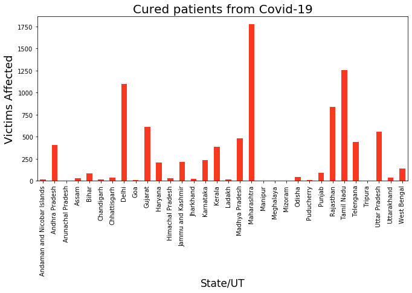

```python
recovery.plot(kind='bar',figsize=(11,5),color='#F93822FF')
plt.title('Cured patients from Covid-19',fontsize=20)
plt.xlabel('State/UT',fontsize=17)
plt.ylabel('Victims Affected',fontsize=18)
plt.show()
```